# PythonBook

## Python与爬虫基础

主讲人： 贾金柱 email： jzjia@math.pku.edu.cn

助教：

- 孔文佳 wjkong@pku.edu.cn
- 王君 jwwwang@pku.edu.cn
- 张鉴心 zhangjx43@pku.edu.cn
- 冯和宁 fenghn9@pku.edu.c

第一次课 Python基础

时间：9月11日 周三10-12节（18:40-21:30）

## 第一章 Python基础

为什么要学习python？

[figure not shown]

Python的安装

- python 主要有两个版本：python2.x 和 python3.x
- 本课主要使用python3.x
- python 有很多版本，我们使用Anaconda, Anaconda3

python 程序的编写

- 一般需要一个编辑器。常用的编辑器有：sublime，atom，pycharm......
- 然后需要一个python解释器，常用的是ipython
- 我们使用jupyter

python 的第一个程序

```python
sum(range(100))
```

```
4950
```

python 当作计算器

```python
(1+100)*100/2
```

```
5050.0
```

```python
(1+99)*99/2
```

```
4950.0
```

$$\int_1^2 xdx$$

```python
from sympy import *
x = symbols('x')
print(integrate(x, (x, 1, 2)))
```

```
3/2
```

输入和输出

```python
x1 = 1
x2 = 13
x = int(input()) ## 输入
while(1):
    print('x=%d,比目标大吗？'%x) ## 输出
    y = input() ## 输入
    if y=='yes':
        x2 = x
        x = (x+x1)//2
    if y=='no':
        print('x=%d,比目标小吗？'%x) ## 输出
        y = input()
        if y=='yes':
            x1 = x
            x = (x+x2)//2
        else:
            print('恭喜你，猜对了！真相只有一个，它就是%d!'%x)
            break
```

```
5
x=5,比目标大吗？
no
x=5,比目标小吗？
yes
x=9,比目标大吗？
no
x=9,比目标小吗？
no
恭喜你，猜对了！真相只有一个，它就是9!
```

本章将学习到什么？

- python 数据类型
- 程序的控制流
- 编写自己的函数
- 文件读写操作

## 第一节 python 最基础知识：数据类型

整数、小数、字符串、布尔值

```python
[10,2,3,1.2E-3,-3e4,1e2,'It', 'is', "a", 'good', 'day','great!',True,False]
```

```
[10,
 2,
 3,
 0.0012,
 -30000.0,
 100.0,
 'It',
 'is',
 'a',
 'good',
 'day',
 'great!',
 True,
 False]
```

注：python中单引号和双引号没有区别

转义字符

```python
print('I\'m \"OK\"!')
```

```
I'm "OK"!
```

```python
print('I\'m learning\n"Python\".\tWhat are you doing?\\')
```

```
I'm learning
"Python".	What are you doing?\
```

```python
print('''hello,
world''')
```

```python
print(r'C:\folder\n') ## raw strings（原始字字符串）
```

```
C:\folder\n
```

布尔运算

```python
[True,2>1,3>2,3>2>1,3>2 and 2>1, 3>2 or 1>2, not 1>2]
```

```
[True, True, True, True, True, True, True]
```

布尔值经常用在判断语句中

```python
score = 86
if score > 85:
    print('成绩优秀')
```

```
成绩优秀
```

```python
[1,2,3,None,4,5,6] ## None 是空值，一种特殊的类型，表示什么都没有
```

变量

- 变量用来存储数据，它的值可以改变。
- 在程序中每一个变量都有一个变量名，用英文字母、数字和下划线表示。
- 不能以数字开头

```python
x=1
x1=2
x2 = 3
x_good = 100
_x = 5
```

```python
[x+1,x1+2,x2+3,x_good-1,_x + 1]
```

```
[2, 4, 6, 99, 6]
```

**动态语言**的特点：

- 不需事先声明变量的类型
- 变量的类型可以改变 如：

```python
x = 1
print(x)
x='你好'
print(x)
```

```
1
你好
```

```python
a = 'ABC'
b = a
a = 'XYZ'
print(b)
```

```
ABC
```

执行 a= 'ABC'时，解释器创建了字符串"ABC",同时创建了变量a，并把a指向字符串

[figure not shown]

执行b=a时，解释器创建了变量b，并把a指向的内容指向了b

[figure not shown]

执行 a= 'XYZ'时，解释器创建了字符串"XYZ",同时把a的指向改变了，指向新建立的字符串

[figure not shown]

一些特殊的操作（运算）

```python
[10/3,10//3,10%3]
```

```
[3.3333333333333335, 3, 1]
```

字符串操作

- 字符串的长度
- 字符串的提取
- 字符串的替换
- 格式化
- 字符串编码问题

```python
x = "I am very happy today!"
print(x)
```

```
I am very happy today!
```

```python
len(x)
```

```
22
```

```python
x.split(' ')
```

```
['I', 'am', 'very', 'happy', 'today!']
```

```python
?x.replace
```

```python
x.replace('!','')
```

```
'I am very happy today'
```

```python
x.replace('I am','You are')
```

```
'You are very happy today!'
```

```python
[x.replace('y','e'),x.replace('y','e',2)]
```

```
['I am vere happe todae!', 'I am vere happe today!']
```

格式化

```python
"%s同学，你的期末考试成绩是 %f，恭喜你，你击败了 %f%%的同类！"%('王思聪',95,(160-2.0)/160*100)
```

```
'王思聪同学，你的期末考试成绩是 95.000000，恭喜你，你击败了 98.750000%的同类！'
```

```python
print("%s同学，你的期末考试成绩是 %f，恭喜你，你击败了 %f%%的同类！"%('王思聪',95,(160-2.0)/160*100))
```

```
王思聪同学，你的期末考试成绩是 95.000000，恭喜你，你击败了 98.750000%的同类！
```

```python
print("%s同学，你的期末考试成绩是 %s，恭喜你，你击败了 %s%%的同类！"%('王思聪',95,(160-2.0)/160*100))
```

```
王思聪同学，你的期末考试成绩是 95，恭喜你，你击败了 98.75%的同类！
```

```python
print("%s同学，你的期末考试成绩是 %.1f，恭喜你，你击败了 %.2f%%的同类！"%('王思聪',95,(160-2.0)/160*100))
```

```
王思聪同学，你的期末考试成绩是 95.0，恭喜你，你击败了 98.75%的同类！
```

```python
print("{0}同学，你的期末考试成绩是{1}，恭喜你，你击败了 {2}%的同类！".format('王思聪',95,(160-2.0)/160*100))
```

```
王思聪同学，你的期末考试成绩是95，恭喜你，你击败了 98.75%的同类！
```

```python
print("{0}同学，你的期末考试成绩是{1:.1f}，恭喜你，你击败了 {2}%的同类！".format('王思聪',95,(160-2.0)/160*100))
```

```
王思聪同学，你的期末考试成绩是95.0，恭喜你，你击败了 98.75%的同类！
```

```python
print('%2d-%02d' % (3, 1))## d代表整数，2代表这个数字占两位字符；
print('%.2f' % 3.1415926)
```

```
 3-01
3.14
```

编码问题

字符串是一种数据类型，但是，字符串比较特殊的是还有一个编码问题。

因为计算机只能处理数字，如果要处理文本，就必须先把文本转换为数字才能处理。最早的计算机在设计时采用8个比特（bit）作为一个字节（byte），所以，一个字节能表示的最大的整数就是255（二进制11111111=十进制255），如果要表示更大的整数，就必须用更多的字节。比如两个字节可以表示的最大整数是65535，4个字节可以表示的最大整数是4294967295。

由于计算机是美国人发明的，因此，最早只有127个字符被编码到计算机里，也就是大小写英文字母、数字和一些符号，这个编码表被称为ASCII编码，比如大写字母A的编码是65，小写字母z的编码是122。

但是要处理中文显然一个字节是不够的，至少需要两个字节，而且还不能和ASCII编码冲突，所以，中国制定了GB2312编码，用来把中文编进去。

你可以想得到的是，全世界有上百种语言，日本把日文编到Shift_JIS里，韩国把韩文编到Euc-kr里，各国有各国的标准，就会不可避免地出现冲突，结果就是，在多语言混合的文本中，显示出来会有乱码。

因此，Unicode应运而生。Unicode把所有语言都统一到一套编码里，这样就不会再有乱码问题了。

现在，捋一捋ASCII编码和Unicode编码的区别：ASCII编码是1个字节，而Unicode编码通常是2个字节。

字母A用ASCII编码是十进制的65，二进制的01000001；

字符0用ASCII编码是十进制的48，二进制的00110000，注意字符'0'和整数0是不同的；

汉字中已经超出了ASCII编码的范围，用Unicode编码是十进制的20013，二进制的01001110 00101101。

你可以猜测，如果把ASCII编码的A用Unicode编码，只需要在前面补0就可以，因此，A的Unicode编码是00000000 01000001。

新的问题又出现了：如果统一成Unicode编码，乱码问题从此消失了。但是，如果你写的文本基本上全部是英文的话，用Unicode编码比ASCII编码需要多一倍的存储空间，在存储和传输上就十分不划算。

所以，本着节约的精神，又出现了把Unicode编码转化为“可变长编码”的UTF-8编码。UTF-8编码把一个Unicode字符根据不同的数字大小编码成1-6个字节，常用的英文字母被编码成1个字节，汉字通常是3个字节，只有很生僻的字符才会被编码成4-6个字节。如果你要传输的文本包含大量英文字符，用UTF-8编码就能节省空间：

[figure not shown]

从上面的表格还可以发现，UTF-8编码有一个额外的好处，就是ASCII编码实际上可以被看成是UTF-8编码的一部分，所以，大量只支持ASCII编码的历史遗留软件可以在UTF-8编码下继续工作。

```python
'王思聪'.encode('utf-8')
```

```
b'\xe7\x8e\x8b\xe6\x80\x9d\xe8\x81\xaa'
```

```python
'中文'.encode('utf-8')
```

```
b'\xe4\xb8\xad\xe6\x96\x87'
```

```python
'ABC'.encode('ascii')
```

```
b'ABC'
```

```python
b'\xe4\xb8\xad\xe6\x96\x87'.decode('utf-8')
```

```
'中文'
```

由于Python源代码也是一个文本文件，所以，当你的源代码中包含中文的时候，在保存源代码时，就需要务必指定保存为UTF-8编码。当Python解释器读取源代码时，为了让它按UTF-8编码读取，我们通常在文件开头写上这两行：

```python
#!/usr/bin/env python3
# -*- coding: utf-8 -*-
```

第一行注释是为了告诉Linux/OS X系统，这是一个Python可执行程序，Windows系统会忽略这个注释；

第二行注释是为了告诉Python解释器，按照UTF-8编码读取源代码，否则，你在源代码中写的中文输出可能会有乱码。

几种常用的Python内置数据结构

- list
- tuple
- dict
- set

list: 有序集合。可以添加、删除、插入数据。

```python
classmates = ['Jim','Peter','Li Lei'] ## list 的创建
```

```python
len(classmates)
```

```
3
```

```python
classmates[0],classmates[2],classmates[1]
```

```
('Jim', 'Li Lei', 'Peter')
```

```python
classmates[3]
```

```
---------------------------------------------------------------------------
IndexError                                Traceback (most recent call last)
<ipython-input-45-81a27e3ce05f> in <module>
----> 1 classmates[3]

IndexError: list index out of range
```

```python
(classmates[-1],classmates[-2],classmates[-3])
```

```
('Li Lei', 'Peter', 'Jim')
```

```python
classmates.append('Han Meimei')
```

```python
classmates
```

```
['Jim', 'Peter', 'Li Lei', 'Han Meimei']
```

```python
classmates.insert(1,'Jack')
```

```python
classmates
```

```
['Jim', 'Jack', 'Peter', 'Li Lei', 'Han Meimei']
```

```python
classmates.pop()
```

```
'Han Meimei'
```

```python
classmates
```

```
['Jim', 'Jack', 'Peter', 'Li Lei']
```

```python
classmates.pop(2)
```

```
'Peter'
```

```python
classmates
```

```
['Jim', 'Jack', 'Li Lei']
```

```python
classmates[1] = 'Sicong'
```

```python
classmates
```

```
['Jim', 'Sicong', 'Li Lei']
```

```python
['Apple','Banana','ipad',3,1,1000,True,False,None]
```

```
['Apple', 'Banana', 'ipad', 3, 1, 1000, True, False, None]
```

```python
L=[['Apple','Banana'],'ipad',[3,1,1000],[True,False,None]]
```

```python
len(L)
```

```
4
```

```python
L[0][0]
```

```
'Apple'
```

```python
L=[]
```

```python
len(L)
```

```
0
```

tuple

tuple:和list类似，不同的是，tuple的元素**不可改变！**更安全！

```python
t = (1,2,3)
```

```python
t,type(t)
```

```
((1, 2, 3), tuple)
```

```python
t=(1,2)
```

```python
t,type(t)
```

```
((1, 2), tuple)
```

```python
t=(1)###陷阱
```

```python
t,type(t)
```

```
(1, int)
```

```python
t=(1,)
```

```python
t,type(t)
```

```
((1,), tuple)
```

```python
a=[1,2,3]
b=a
a[2]=4
```

```python
b ### b 也变化了！！！！
```

```
[1, 2, 4]
```

Set

set:可以看成数学意义上的无序和无重复元素的集合，因此，两个set可以做数学意义上的交集、并集等操作：

```python
s1 = set([1, 2, 3])
s2 = set([1, 2, 4])
```

```python
s1 & s2
```

```
{1, 2}
```

```python
s1 | s2
```

```
{1, 2, 3, 4}
```

```python
s1.add(4)
```

```python
s1
```

```
{1, 2, 3, 4}
```

```python
s1.remove(4)
```

```python
s1
```

```
{1, 2, 3}
```

```python
x = [1,2,3,4,5,4,3,2,1]
```

```python
set(x)
```

```
{1, 2, 3, 4, 5}
```

```python
x = {1,2,3,2,1}
```

```python
x
```

```
{1, 2, 3}
```

```python
t = ('a', 'b', ['A', 'B'])
t[2][0] = 'X'
t[2][1] = 'Y'
```

```python
t
```

```
('a', 'b', ['X', 'Y'])
```

Dict

Dict,很多书上又称为健值对（key:value） pairs,具有极快的查询速度。

```python
names = ['Michael', 'Bob', 'Tracy']
scores = [95, 75, 85]
```

```python
d = {'Michael': 95, 'Bob': 75, 'Tracy': 85}
```

```python
d
```

```
{'Michael': 95, 'Bob': 75, 'Tracy': 85}
```

```python
d['Bob']
```

```
75
```

```python
d['Jim'] = 90
```

```python
d
```

```
{'Michael': 95, 'Bob': 75, 'Tracy': 85, 'Jim': 90}
```

```python
d['Li Lei']
```

```
---------------------------------------------------------------------------
KeyError                                  Traceback (most recent call last)
<ipython-input-95-a6ffd4375a17> in <module>
----> 1 d['Li Lei']

KeyError: 'Li Lei'
```

```python
'Li Lei' in d
```

```
False
```

```python
d.get('Jim')
```

```
90
```

```python
d.get('Li Lei')
```

```python
d.get('Li Lei',-1)
```

```
-1
```

```python
d.pop('Jim')
```

```
90
```

```python
d
```

```
{'Michael': 95, 'Bob': 75, 'Tracy': 85}
```

请务必注意，dict内部存放的顺序和key放入的顺序是没有关系的。

和list比较，dict有以下几个特点：

```
查找和插入的速度极快，不会随着key的增加而变慢；
需要占用大量的内存，内存浪费多。
```

而list相反：

```
查找和插入的时间随着元素的增加而增加；
占用空间小，浪费内存很少。
```

所以，dict是用空间来换取时间的一种方法。

dict可以用在需要高速查找的很多地方，在Python代码中几乎无处不在，正确使用dict非常重要，需要牢记的第一条就是dict的key必须是不可变对象。

```python
d.keys()
```

```
dict_keys(['Michael', 'Bob', 'Tracy'])
```

```python
d.values()
```

```
dict_values([95, 75, 85])
```

可变对象和不可变对象

对于可变对象，比如list，对list进行操作，list内部的内容是会变化的，比如：

```python
a = ['c', 'b', 'a']
```

```python
a.sort()
```

```python
a ## a 变化了
```

```
['a', 'b', 'c']
```

```python
a = 'abc'
```

```python
a.replace('a','A')
```

```
'Abc'
```

```python
a ## a 不变
```

```
'abc'
```

## 第二节 控制流

- 条件
- 循环

if <条件判断1>: <执行1> elif <条件判断2>: <执行2> elif <条件判断3>: <执行3> else: <执行4>

```python
age = 3
if age >= 18:
    print('adult')
elif age >= 6:
    print('teenager')
else:
    print('kid')
```

```
kid
```

```python
age = 20
if age >= 6:
    print('teenager')
elif age >= 18:
    print('adult')
else:
    print('kid')
```

```
teenager
```

循环

- for
- while
- break
- continue

```python
for name in ['Bob','Jim','Li Lei']:
    print('send %s an email!'%name)
```

```
send Bob an email!
send Jim an email!
send Li Lei an email!
```

```python
names = ['Bob','Jim','Li Lei']
k = 0
while(1):
    name = names[k]
    print('send %s an email!'%name)
    k = k+1
    if k >=len(names):
        break
```

```python
for i in range(10):
    if i%2 ==0:
        continue
    else:
        print('%d is an odd number!'%i)
```

```
1 is an odd number!
3 is an odd number!
5 is an odd number!
7 is an odd number!
9 is an odd number!
```

# 第三节 函数

python 内置了很多函数，正确调用函数可以高效地完成任务

```python
abs(-100),min(1,2,3),min([1,2,3])
```

```
(100, 1, 1)
```

```python
min([1,2,3],[1,2])
```

```
[1, 2]
```

```python
int('123'),float('1.2'),str(100)
```

```
(123, 1.2, '100')
```

函数名是可以改变的，和变量名意义类似，函数名是用来存放函数的，所以它指向一个函数

```python
my_abs = abs
```

```python
my_abs(-100)
```

```
100
```

自定义函数

```python
def quadratic(x,a=1,b=2,c=0): ## 默认参数，必须放在最后，且是不可变对象
    res = a*x**2+b*x+c
    return res
```

```python
import numpy as np
x = np.linspace(-5,3,20)
y = quadratic(x)
```

```python
%matplotlib inline
import matplotlib.pyplot as plt
```

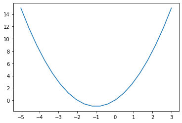

```python
plt.plot(x,y)
```

```python
def fact(n):
    if n==1:
        return 1
    return n * fact(n - 1) ## 在函数内部调用自身，这样的函数叫递归函数
```

```python
fact(6)
```

```
720
```

## 第四节 文件操作

```python
f = open('./test.txt', 'w')
f.write('Hello, world!')
f.close()
```

```python
with open('./test.txt', 'w') as f:
    f.write('Hello, world!')
```

```python
f = open('./test.txt', 'r')
f.read()
f.close()
```

```python
with open('./test.txt', 'r') as f:
    print(f.read())
```

序列化

我们把变量从内存中变成可存储或传输的过程称之为序列化，在Python中叫pickling，在其他语言中也被称之为serialization，marshalling，flattening等等，都是一个意思。

序列化之后，就可以把序列化后的内容写入磁盘，或者通过网络传输到别的机器上。

反过来，把变量内容从序列化的对象重新读到内存里称之为反序列化，即unpickling。

Python提供了pickle模块来实现序列化。

```python
import pickle
d = dict(name='Bob', age=30, score=88)
f = open('dump.pkl', 'wb')
pickle.dump(d, f)
f.close()
```

```python
f = open('dump.pkl', 'rb')
d = pickle.load(f)
f.close()
d
```

## 第五节 一些高级特性

```python
L = ['Michael', 'Sarah', 'Tracy', 'Bob', 'Jack']
```

```python
L[:3] ## 切片，slice
```

```python
L[3:]
```

```python
L[:]
```

```python
L[:-1]
```

```python
L[-1:]
```

```python
L = list(range(100))
```

```python
L[:10:2]
```

```python
L[::5]
```

```python
"ABCDE"[1:5:2],"ABCDE"[-1:-5:-1]
```

```python
[x * x for x in range(1, 11)] ## 列表生成式
```

## 作业

1.用python写出一个数学竖式。

用键盘输入三个量：第一个数字、第二个数字、+或-号

输出：一个漂亮的数学竖式，如下图所示。

[figure not shown]

2.用python编写24点小游戏。

要求：从键盘输入4个数字，每个在1-10（包含）之间

判断是否可以用 +-*/ 通过运算得到结果24，并输出运算过程

结果越简洁越好

[figure not shown]

3.对附件的英文小说: pride_and_prejudice.txt

统计出其中使用的单词数量，

并计算每一个单词的出现次数。

Report最多的10个单词。

4.找出10000以内的所有孪生素数对。

5.针对附件的曲线数据(sample.txt)，画出曲线图。(最后的曲线图处，有一个详细的说明，包括横轴、纵轴分别是什么) 数据读取后，数据长成这样：

```python
import csv
lines = []
with open('sample.txt', 'r') as csvf:
    k = 0
    for line in csv.reader(csvf):
        k = k +1
        lines.append(line[0].split('\t'))
```

```python
lines[0][0],lines[0][0][1:]
```

```
('\ufeff18286230', '18286230')
```

```python
lines[0]
```

```
['\ufeff18286230',
 '2019-04-19 19:33:42.000',
 '-2',
 '1.5',
 '0',
 '0x00000000E416B13E89A3093F5B60443FF066723F2009953FE1F3AA3F37…',
 '76271592                                          ']
```

```python
lines[1]
```

各列名字如下：'id1','timestamp','ind','sampleTime','angleOffset','codes','identifier'

id1: 曲线id；ind=-1：代表是Torque数据；ind = -2:代表是Angle数据，sampleTime 代表多久采样一次；codes是真正的数据

```python
import struct
codes = lines[0][5]
hexcode = codes[2:10]
print(hexcode)
bts = bytes.fromhex(hexcode)
print(bts)
struct.unpack('<f',bts)
struct.unpack('<f',bts)[0]
```

```
00000000
b'\x00\x00\x00\x00'
```

```
0.0
```

```python
codes = lines[0][5]
hexcode = codes[10:18]
print(hexcode)
bts = bytes.fromhex(hexcode)
print(bts)
struct.unpack('<f',bts)
struct.unpack('<f',bts)[0]
```

```
E416B13E
b'\xe4\x16\xb1>'
```

```
0.3458777666091919
```

[figure not shown]

这幅图中，横轴代表angle，纵轴代表toruqe。在数据中，id1相同的两行数据，一行代表torque（ind=-1），一行代表angle（ind=-2）。数据都是用codes表示的。需要先解码。有了angle 和 torque，就可以画上面的图形了。多次调用plt.plot(),可以同时画出所有的曲线。

第二次课 【停课】 时间：9月13日 周五10-12节（18:40-21:30） 【停课】

第二次课 Python的面向对象编程 时间：9月18日 周三10-12节（18:40-21:30）

## 第二章 面向对象编程

面向对象最重要的概念就是类（Class）和实例（Instance）

- 类，类型的简称，相当于自定制的新的类型
- 类是模板，是抽象的
- 而实例是具体的，根据类创建出来的一个个具体的“对象”
- 每个对象都拥有相同的方法，但各自的数据可能不同。
- 类和函数一样，可以大大地减少代码的重复编写

例如：在终端输出如下信息

小明，10岁，男，上山去砍柴

小明，10岁，男，最爱打游戏

........

老李，90岁，男，上山去砍柴

老李，90岁，男，开车去东北

老李，90岁，男，最爱打游戏

```python
def kanchai(name, age, gender):
    print("%s,%s岁,%s,上山去砍柴" %(name, age, gender))


def qudongbei(name, age, gender):
    print("%s,%s岁,%s,开车去东北" %(name, age, gender))


def dayouxi(name, age, gender):
    print("%s,%s岁,%s,最爱打游戏" %(name, age, gender))
```

```python
kanchai('小明', 10, '男')
qudongbei('小明', 10, '男')
dayouxi('小明', 10, '男')

kanchai('老李', 90, '男')
qudongbei('老李', 90, '男')
dayouxi('老李', 90, '男')
```

```
小明,10岁,男,上山去砍柴
小明,10岁,男,开车去东北
小明,10岁,男,最爱打游戏
老李,90岁,男,上山去砍柴
老李,90岁,男,开车去东北
老李,90岁,男,最爱打游戏
```

```python
class sport:

    def __init__(self, name, age ,gender):
        self.name = name
        self.age = age
        self.gender = gender

    def kanchai(self):
        print("%s,%s岁,%s,上山去砍柴" %(self.name, self.age, self.gender))

    def qudongbei(self):
        print("%s,%s岁,%s,开车去东北" %(self.name, self.age, self.gender))

    def dayouxi(self):
        print("%s,%s岁,%s,最爱打游戏" %(self.name, self.age, self.gender))
```

```python
xiaoming = sport('小明', 10, '男')
xiaoming.kanchai()
xiaoming.qudongbei()
xiaoming.dayouxi()

laoli = sport('老李', 90, '男')
laoli.kanchai()
laoli.qudongbei()
laoli.dayouxi()
```

```
小明,10岁,男,上山去砍柴
小明,10岁,男,开车去东北
小明,10岁,男,最爱打游戏
老李,90岁,男,上山去砍柴
老李,90岁,男,开车去东北
老李,90岁,男,最爱打游戏
```

## 第一节 类和实例

```python
class Student(object):
    pass
```

`class`后面紧接着是类名，即`Student`，类名通常是大写开头的单词，紧接着是(`object`)，表示该类是从哪个类继承下来的，继承的概念我们后面再讲，通常，如果没有合适的继承类，就使用`object`类，这是所有类最终都会继承的类 **[可以不写]**。

定义好了Student类（它是一个新类型），就可以根据Student类（型）创建出Student的实例（变量），创建实例是通过类名+()实现的：

```python
Sicong = Student()
```

```python
Sicong
```

```
<__main__.Student at 0x10eff8b38>
```

```python
Student
```

```
__main__.Student
```

可以看到，变量Sicong指向的就是一个Student的实例，后面的0x......是内存地址，每个object的地址都不一样，而Student本身则是一个类。

可以自由地给一个实例变量绑定属性，比如，给实例Sicong绑定一个name属性和一个score属性：

```python
Sicong.name = 'Sicong Wang'
```

```python
Sicong
```

```
<__main__.Student at 0x10eff8b38>
```

```python
Sicong.score = 99
```

```python
Sicong.name,Sicong.score
```

```
('Sicong Wang', 99)
```

由于类可以起到模板的作用，因此，可以在创建实例的时候，把一些我们认为必须绑定的属性强制填写进去。通过定义一个特殊的__init__方法，在创建实例的时候，就把name，score等属性绑上去：

```python
class Student(object):

    def __init__(self, name, score):
        self.name = name
        self.score = score
```

__init__方法的第一个参数永远是self，表示创建的实例本身，因此，在__init__方法内部，就可以把各种属性绑定到self，因为self就指向创建的实例本身。

有了__init__方法，在创建实例的时候，就不能传入空的参数了，必须传入与__init__方法匹配的参数，但self不需要传，Python解释器自己会把实例变量传进去：

```python
Sicong = Student('Sicong Wang',95)
```

```python
Sicong,print(Sicong)
```

```
<__main__.Student object at 0x10efd1588>
```

```
(<__main__.Student at 0x10efd1588>, None)
```

```python
Sicong.name,Sicong.score
```

```
('Sicong Wang', 95)
```

和普通的函数相比，在类中定义的函数只有一点不同，就是第一个参数永远是实例变量self，并且调用时，不用传递该参数。除此之外，类的方法和普通函数没有什么区别，所以，你仍然可以用默认参数等。

```python
class Student(object):

    def __init__(self, name, score):
        self.name = name
        self.score = score

    def __str__(self):
        return 'name: %s\nscore: %s'%(self.name, self.score)
```

```python
Sicong = Student('Sicong Wang',95)
```

```python
print(Sicong)
```

```
name: Sicong Wang
score: 95
```

```python
Sicong
```

```
<__main__.Student at 0x1124a47b8>
```

```python
class Student(object):

    def __init__(self, name, score):
        self.name = name
        self.score = score

    def __str__(self):
        return 'name: %s\nscore: %s'%(self.name, self.score)
    __repr__ = __str__
```

```python
Sicong = Student('Sicong Wang',95)
```

```python
Sicong
```

```
name: Sicong Wang
score: 95
```

- 在python中方法名如果是__xxxx__()的，那么就有特殊的功能，因此叫做“魔法”方法
- 当使用print输出对象的时候，只要自己定义了__str__(self)方法，那么就会打印从在这个方法中return的数据
- __str__方法需要返回一个字符串，当做这个对象的描写
- __repr__ 也是用来描述对象的，一般和 __str__方法是一样的

**数据封装** 面向对象编程的一个重要特点就是数据封装。在上面的Student类中，每个实例就拥有各自的name和score这些数据。我们可以通过函数来访问这些数据，比如打印一个学生的成绩：

```python
def print_score(std):
     print('%s: %s' % (std.name, std.score))

print_score(Sicong)
```

```
Sicong Wang: 95
```

但是，既然Student实例本身就拥有这些数据，要访问这些数据，就没有必要从外面的函数去访问，可以直接在Student类的内部定义访问数据的函数，这样，就把“数据”给封装起来了。这些封装数据的函数是和Student类本身是关联起来的，我们称之为**类的方法**：

```python
class Student(object):

    def __init__(self, name, score):
        self.name = name
        self.score = score

    def __str__(self):
        return 'name: %s\nscore: %s'%(self.name, self.score)
    __repr__ = __str__

    def print_score(self):
        print('%s: %s' % (self.name, self.score))
```

```python
Sicong = Student('Sicong Wang',95)
```

要定义一个方法，除了第一个参数是self外，其他和普通函数一样。要调用一个方法，只需要在实例变量上直接调用，除了self不用传递，其他参数正常传入：

```python
Sicong.print_score()
```

```
Sicong Wang: 95
```

这样一来，我们从外部看Student类，就只需要知道，创建实例需要给出name和score，而如何打印，都是在Student类的内部定义的，这些数据和逻辑被“封装”起来了，调用很容易，但却不用知道内部实现的细节。

类其实就是自己定义的新的类型，和python内置的类型并没有本质不同。参考如下例子。

```python
X = list(range(0,10,2))
```

```python
X
```

```
[0, 2, 4, 6, 8]
```

```python
X.index(2)
```

```
1
```

```python
X.insert(1,1)
```

```python
X
```

```
[0, 1, 2, 4, 6, 8]
```

**小结**

- 类是创建实例的模板，是抽象的，而实例则是一个一个具体的对象，各个实例拥有的数据都互相独立，互不影响；
- 方法就是与实例绑定的函数，和普通函数不同，方法可以直接访问实例的数据；
- 通过在实例上调用方法，我们就直接操作了对象内部的数据，但无需知道方法内部的实现细节。
- 和静态语言不同，Python允许对实例变量绑定任何数据，也就是说，对于两个实例变量，虽然它们都是同一个类的不同实例，但拥有的变量名称都可能不同：

```python
Jim = Student('Jim Green', 80)
Lei = Student('Lei Li', 90)
Jim.age = 12
Jim.age
```

```
12
```

```python
Lei.age
```

```
---------------------------------------------------------------------------
AttributeError                            Traceback (most recent call last)
<ipython-input-46-b813b682d734> in <module>
----> 1 Lei.age

AttributeError: 'Student' object has no attribute 'age'
```

## 第二节 访问限制

在Class内部，可以有属性和方法，而外部代码可以通过直接调用实例变量的方法来操作数据，这样，就隐藏了内部的复杂逻辑。

但是，从前面Student类的定义来看，外部代码还是可以自由地修改一个实例的name、score属性：

```python
Jim = Student('Jim Green', 80)
```

```python
Jim.score
```

```
80
```

```python
Jim.score =99
```

```python
print(Jim)
```

```
name: Jim Green
score: 99
```

如果要让内部属性不被外部访问，可以把属性的名称前加上两个下划线__，在Python中，实例的变量名如果以__开头，就变成了一个私有变量（private），只有内部可以访问，外部不能访问，所以，我们把Student类改一改：

```python
class Student(object):

    def __init__(self, name, score):
        self.__name = name
        self.__score = score

    def __str__(self):
        return 'name: %s\nscore: %s'%(self.__name, self.__score)
    __repr__ = __str__
    def print_score(self):
        print('%s: %s' % (self.__name, self.__score))
```

```python
Jim = Student('Jim Green', 80)
```

```python
print(Jim)
```

```
name: Jim Green
score: 80
```

```python
Jim
```

```
name: Jim Green
score: 80
```

改完后，对于外部代码来说，没什么变动，但是已经无法从外部访问实例变量.__name和实例变量.__score了：

```python
Jim.__name
```

```
---------------------------------------------------------------------------
AttributeError                            Traceback (most recent call last)
<ipython-input-37-95a308f3b544> in <module>
----> 1 Jim.__name

AttributeError: 'Student' object has no attribute '__name'
```

这样就确保了外部代码不能随意修改对象内部的状态，这样通过访问限制的保护，代码更加健壮。

但是如果外部代码要获取name和score怎么办？可以给Student类增加get_name和get_score这样的方法：

```python
class Student(object):

    def __init__(self, name, score):
        self.__name = name
        self.__score = score

    def __str__(self):
        return 'name: %s\nscore: %s'%(self.__name, self.__score)
    __repr__ = __str__


    def print_score(self):
        print('%s: %s' % (self.__name, self.__score))

    def get_name(self):
        return self.__name
    def get_score(self):
        return self.__score
```

```python
bart = Student('Bart Simpson', 59)
```

```python
bart
```

```
name: Bart Simpson
score: 59
```

```python
bart.get_name(),bart.get_score()
```

```
('Bart Simpson', 59)
```

问题：如果又要允许外部代码修改score怎么办？可以再给Student类增加set_score方法：

```python
class Student(object):

    def __init__(self, name, score):
        self.__name = name
        self.__score = score

    def __str__(self):
        return 'name: %s\nscore: %s'%(self.__name, self.__score)

    def print_score(self):
        print('%s: %s' % (self.__name, self.__score))

    def get_name(self):
        return self.__name
    def get_score(self):
        return self.__score
    def set_score(self,score): ## 注意：这个函数没有返回值，而是改变了instance的属性的值
        self.__score = score
```

```python
bart = Student('Bart Simpson', 59)
```

```python
bart.get_score()
```

```
59
```

```python
bart.set_score(99)
```

```python
bart.get_score()
```

```
99
```

```python
bart.score = 93
```

```python
print(bart)
```

```
name: Bart Simpson
score: 99
```

你也许会问，原先那种直接通过bart.score = 99也可以修改啊，为什么要定义一个方法大费周折？因为在方法中，可以对参数做检查，避免传入无效的参数：

```python
class Student(object):

    def __init__(self, name, score):
        self.__name = name
        self.__score = score

    def __str__(self):
        return 'name: %s\nscore: %s'%(self.__name, self.__score)

    def print_score(self):
        print('%s: %s' % (self.__name, self.__score))

    def get_name(self):
        return self.__name
    def get_score(self):
        return self.__score
    def set_score(self,score):
        if 0<=score<=100:
            self.__score = score
        else:
            raise ValueError('bad score')
```

```python
bart = Student('Bart Simpson', 99)
```

```python
bart.set_score(120)
```

```
---------------------------------------------------------------------------
ValueError                                Traceback (most recent call last)
<ipython-input-53-2043a071494c> in <module>
----> 1 bart.set_score(120)

<ipython-input-51-b91f610a47c6> in set_score(self, score)
     19             self.__score = score
     20         else:
---> 21             raise ValueError('bad score')

ValueError: bad score
```

最后注意下面的这种错误写法：

```python
bart = Student('Bart Simpson', 59)
bart.get_name()
bart.__name = 'New Name' # 设置__name变量！
bart.__name
```

```
'New Name'
```

表面上看，外部代码“成功”地设置了__name变量，但实际上这个__name变量和class内部的__name变量不是一个变量！内部的__name变量已经被Python解释器自动改成了*Student\*_name，而外部代码给bart新增了一个__name变量。不信试试：

```python
bart.get_name()
```

```
'Bart Simpson'
```

双下划线开头的实例变量是不是一定不能从外部访问呢？其实也不是。不能直接访问__name是因为Python解释器对外把__name变量改成了*Student\*_name，所以，仍然可以通过*Student\*_name来访问__name变量：

```python
bart._Student__name
```

```
'Bart Simpson'
```

```python
bart._Student__name = 'bart'
```

```python
print(bart)
```

```
name: bart
score: 59
```

总的来说就是，Python本身没有任何机制阻止你干坏事。

## 第三节 继承和多态

在OOP程序设计中，当我们定义一个class的时候，可以从某个现有的class继承，新的class称为子类（Subclass），而被继承的class称为基类、父类或超类（Base class、Super class）。

继承可以把父类的所有功能都直接拿过来，这样就不必从零做起，子类只需要新增自己特有的方法，也可以把父类不适合的方法覆盖重写。

比如，我们已经编写了一个名为Animal的class，有一个run()方法可以直接打印：

```python
class Animal(object):
    def run(self):
        print('Animal is running...')
```

当我们需要编写Dog和Cat类时，就可以直接从Animal类继承：

```python
class Dog(Animal):
    pass

class Cat(Animal):
    pass
```

对于Dog来说，Animal就是它的父类，对于Animal来说，Dog就是它的子类。Cat和Dog类似。

继承有什么好处？最大的好处是子类获得了父类的全部功能。由于Animial实现了run()方法，因此，Dog和Cat作为它的子类，什么事也没干，就自动拥有了run()方法：

```python
dog = Dog()
dog.run()

cat = Cat()
cat.run()
```

```
Animal is running...
Animal is running...
```

当然，也可以对子类增加一些方法，比如Dog类：

```python
class Dog(Animal):

    def eat(self):
        print('Eating meat...')
```

```python
dog = Dog()
dog.run()
dog.eat()
```

```
Animal is running...
Eating meat...
```

继承的第二个好处需要我们对代码做一点改进。你看到了，无论是Dog还是Cat，它们run()的时候，显示的都是Animal is running...，符合逻辑的做法是分别显示Dog is running...和Cat is running...，因此，对Dog和Cat类改进如下：

```python
class Dog(Animal):

    def run(self):
        print('Dog is running...')

class Cat(Animal):

    def run(self):
        print('Cat is running...')
```

```python
dog = Dog()
dog.run()

cat = Cat()
cat.run()
```

```
Dog is running...
Cat is running...
```

**多态**

要理解什么是多态，我们首先要对数据类型再作一点说明。当我们定义一个class的时候，我们实际上就定义了一种数据类型。我们定义的数据类型和Python自带的数据类型，比如str、list、dict没什么两样：

```python
a = list() # a是list类型
b = Animal() # b是Animal类型
c = Dog() # c是Dog类型
```

```python
isinstance(a, list)
isinstance(b, Animal)
isinstance(c, Dog)
```

```
True
```

```python
isinstance(c, Animal)
```

```
True
```

```python
b = Animal()
isinstance(b, Dog)
```

```
False
```

要理解多态的好处，我们还需要再编写一个函数，这个函数接受一个Animal类型的变量：

```python
def run_twice(animal):
    animal.run()
    animal.run()
```

当我们传入Animal的实例时，run_twice()就打印出：

```python
run_twice(Animal())
```

```
Animal is running...
Animal is running...
```

```python
run_twice(Dog())
```

```
Dog is running...
Dog is running...
```

```python
run_twice(Cat())
```

```
Cat is running...
Cat is running...
```

```python
class Tortoise(Animal):
    def run(self):
        print('Tortoise is running slowly...')
```

```python
 run_twice(Tortoise())
```

```
Tortoise is running slowly...
Tortoise is running slowly...
```

你会发现，新增一个Animal的子类，不必对run_twice()做任何修改，实际上，任何依赖Animal作为参数的函数或者方法都可以不加修改地正常运行，原因就在于多态。

多态的好处就是，当我们需要传入Dog、Cat、Tortoise……时，我们只需要接收Animal类型就可以了，因为Dog、Cat、Tortoise……都是Animal类型，然后，按照Animal类型进行操作即可。由于Animal类型有run()方法，因此，传入的任意类型，只要是Animal类或者子类，就会自动调用实际类型的run()方法，这就是多态的意思：

对于一个变量，我们只需要知道它是Animal类型，无需确切地知道它的子类型，就可以放心地调用run()方法，而具体调用的run()方法是作用在Animal、Dog、Cat还是Tortoise对象上，由运行时该对象的确切类型决定，这就是多态真正的威力：调用方只管调用，不管细节，而当我们新增一种Animal的子类时，只要确保run()方法编写正确，不用管原来的代码是如何调用的。

甚至于，连Animal的子类都不用，只要它有一个run方法就行！！！

这就是著名的“开闭”原则：

- 对扩展开放：允许新增Animal子类；允许“类似”Animal类
- 对修改封闭：不需要修改依赖Animal类型的run_twice()等函数。

```python
class car():
    def run(self):
        print('Car is running very fast!!!')
```

```python
class Bmw(car):
    def run(self):
        print('bmw is running very fast!!!')
```

```python
bmw = Bmw()
```

```python
 run_twice(bmw)
```

```
bmw is running very fast!!!
bmw is running very fast!!!
```

## 第四节 获取对象信息

当我们拿到一个对象的引用时，如何知道这个对象是什么类型、有哪些方法呢？

- type()
- isinstance()
- dir()
- getattr()
- setattr()
- hasattr()

```python
type(123),type('abc'),type(None),type(abs),type(bart)
```

```
(int, str, NoneType, builtin_function_or_method, __main__.Student)
```

type()函数返回的是什么类型呢？它返回对应的Class类型

```python
type(123) == int
```

```
True
```

```python
type('abc') == str
```

```
True
```

```python
a = Animal()
d = Dog()
```

```python
class Husky(Dog):
    pass
```

```python
h = Husky()
```

object -> Animal -> Dog -> Husky

```python
type(h)
```

```
__main__.Husky
```

```python
isinstance(h,Husky),isinstance(h,Dog),isinstance(h,Animal),isinstance(h,object)
```

```
(True, True, True, True)
```

```python
isinstance(d,Husky),isinstance(d,Dog),isinstance(d,Animal),isinstance(d,object)
```

```
(False, True, True, True)
```

并且还可以判断一个变量是否是某些类型中的一种，比如下面的代码就可以判断是否是list或者tuple：

```python
isinstance([1, 2, 3], (list, tuple))
```

```
True
```

```python
isinstance((1, 2, 3), (list, tuple))
```

```
True
```

```python
isinstance((1,), (list, tuple))
```

```
True
```

dir()返回一个对象的所有属性和方法

```python
dir(str)
```

```
['__add__',
 '__class__',
 '__contains__',
 '__delattr__',
 '__dir__',
 '__doc__',
 '__eq__',
 '__format__',
 '__ge__',
 '__getattribute__',
 '__getitem__',
 '__getnewargs__',
 '__gt__',
 '__hash__',
 '__init__',
 '__init_subclass__',
 '__iter__',
 '__le__',
 '__len__',
 '__lt__',
 '__mod__',
 '__mul__',
 '__ne__',
 '__new__',
 '__reduce__',
 '__reduce_ex__',
 '__repr__',
 '__rmod__',
 '__rmul__',
 '__setattr__',
 '__sizeof__',
 '__str__',
 '__subclasshook__',
 'capitalize',
 'casefold',
 'center',
 'count',
 'encode',
 'endswith',
 'expandtabs',
```

[output cut: 23 more lines]

```
 'rfind',
 'rindex',
 'rjust',
 'rpartition',
 'rsplit',
 'rstrip',
 'split',
 'splitlines',
 'startswith',
 'strip',
 'swapcase',
 'title',
 'translate',
 'upper',
 'zfill']
```

```python
dir('ABC')
```

```
['__add__',
 '__class__',
 '__contains__',
 '__delattr__',
 '__dir__',
 '__doc__',
 '__eq__',
 '__format__',
 '__ge__',
 '__getattribute__',
 '__getitem__',
 '__getnewargs__',
 '__gt__',
 '__hash__',
 '__init__',
 '__init_subclass__',
 '__iter__',
 '__le__',
 '__len__',
 '__lt__',
 '__mod__',
 '__mul__',
 '__ne__',
 '__new__',
 '__reduce__',
 '__reduce_ex__',
 '__repr__',
 '__rmod__',
 '__rmul__',
 '__setattr__',
 '__sizeof__',
 '__str__',
 '__subclasshook__',
 'capitalize',
 'casefold',
 'center',
 'count',
 'encode',
 'endswith',
 'expandtabs',
```

[output cut: 23 more lines]

```
 'rfind',
 'rindex',
 'rjust',
 'rpartition',
 'rsplit',
 'rstrip',
 'split',
 'splitlines',
 'startswith',
 'strip',
 'swapcase',
 'title',
 'translate',
 'upper',
 'zfill']
```

```python
dir(h)
```

```
['__class__',
 '__delattr__',
 '__dict__',
 '__dir__',
 '__doc__',
 '__eq__',
 '__format__',
 '__ge__',
 '__getattribute__',
 '__gt__',
 '__hash__',
 '__init__',
 '__init_subclass__',
 '__le__',
 '__lt__',
 '__module__',
 '__ne__',
 '__new__',
 '__reduce__',
 '__reduce_ex__',
 '__repr__',
 '__setattr__',
 '__sizeof__',
 '__str__',
 '__subclasshook__',
 '__weakref__',
 'run']
```

```python
'ABC'.find('B')
```

```
1
```

类似__ xxx__的属性和方法在Python中都是有特殊用途的，比如__len__方法返回长度。 在Python中，如果你调用len()函数试图获取一个对象的长度，实际上，在len()函数内部， 它自动去调用该对象的__ len__()方法， 所以，下面的代码是等价的：

```python
 len('ABC'), 'ABC'.__len__()
```

```
(3, 3)
```

仅仅把属性和方法列出来是不够的，配合getattr()、setattr()以及hasattr()，我们可以直接操作一个对象的状态：

```python
class MyObject(object):
     def __init__(self):
         self.x = 9
     def power(self):
         return self.x * self.x
```

```python
obj = MyObject()
```

```python
hasattr(obj, 'x') # 有属性'x'吗？
```

```
True
```

```python
obj.x
```

```
9
```

```python
hasattr(obj, 'power')
```

```
True
```

```python
hasattr(MyObject, 'power')
```

```
True
```

```python
hasattr(MyObject, 'x')
```

```
False
```

如果试图获取不存在的属性，会抛出AttributeError的错误：

可以传入一个default参数，如果属性不存在，就返回默认值：

```python
getattr(obj, 'z')
```

```
---------------------------------------------------------------------------
AttributeError                            Traceback (most recent call last)
<ipython-input-103-95c3c0ec4e01> in <module>
----> 1 getattr(obj, 'z')

AttributeError: 'MyObject' object has no attribute 'z'
```

```python
getattr(obj, 'z',404)
```

```
404
```

## 第五节 实例属性和类属性

由于Python是动态语言，根据类创建的实例可以任意绑定属性。

给实例绑定属性的方法是通过实例变量，或者通过self变量：

```python
class Student(object):
    def __init__(self, name):
        self.name = name

s = Student('Bob')
s.score = 90
```

但是，如果`Student`类本身需要绑定一个属性呢？可以直接在class中定义属性，这种属性是类属性，归Student类所有：

```python
class Student(object):
    name = 'Student'
```

```python
s = Student()
```

```python
s.name,Student.name ## 当我们定义了一个类属性后，这个属性虽然归类所有，但类的所有实例都可以访问到。来测试一下：
```

```
('Student', 'Student')
```

```python
s.name='micheal'
```

```python
s.name,Student.name
```

```
('micheal', 'Student')
```

```python
del s.name
```

```python
s.name
```

```
'Student'
```

从上面的例子可以看出，在编写程序的时候，千万不要对实例属性和类属性使用相同的名字，因为相同名称的实例属性将屏蔽掉类属性，但是当你删除实例属性后，再使用相同的名称，访问到的将是类属性。

```python
class Student(object):
    count = 0

    def __init__(self, name):
        self.name = name
        Student.count += 1
```

```python
if Student.count != 0:
    print('测试失败!')
else:
    bart = Student('Bart')
    if Student.count != 1:
        print('测试失败!')
    else:
        lisa = Student('Bart')
        if Student.count != 2:
            print('测试失败!')
        else:
            print('Students:', Student.count)
            print('测试通过!')
```

```
Students: 2
测试通过!
```

```python
x2 = Student('b')
```

```python
x2.count
```

```
3
```

```python
Student.count
```

```
3
```

```python
x3  = Student('b')
```

```python
Student.count
```

```
4
```

实例属性属于各个实例所有，互不干扰；

类属性属于类所有，所有实例共享一个属性；

不要对实例属性和类属性使用相同的名字，否则将产生难以发现的错误。

## 第六节 面向对象高级编程

- __slots__
- 多重继承

如果我们想要限制实例的属性怎么办？比如，只允许对Student实例添加name和age属性。

为了达到限制的目的，Python允许在定义class的时候，定义一个特殊的__slots__变量，来限制该class实例能添加的属性：

```python
class Student(object):
    __slots__ = ('name', 'age') # 用tuple定义允许绑定的属性名称
```

```python
s = Student()
s.name = 'Michael'
s.age = 25
```

```python
s.score = 99
```

```
---------------------------------------------------------------------------
AttributeError                            Traceback (most recent call last)
<ipython-input-114-43bad5f5e779> in <module>
----> 1 s.score = 99

AttributeError: 'Student' object has no attribute 'score'
```

由于'score'没有被放到**slots**中，所以不能绑定score属性，试图绑定score将得到AttributeError的错误。

使用**slots**要注意，**slots**定义的属性仅对当前类实例起作用，对继承的子类是不起作用的：

```python
class GraduateStudent(Student):
    pass

g = GraduateStudent()
g.score = 9999
```

**多重继承** 继承多个父类

```python
class Runnable(object):
    def run(self):
        print('Running...')

class Flyable(object):
    def fly(self):
        print('Flying...')
```

```python
class Animal(object):
    pass

# 大类:
class Mammal(Animal):
    pass

class Bird(Animal):
    pass

# 各种动物:
class Dog(Mammal):
    pass

class Bat(Mammal):
    pass

class Parrot(Bird):
    pass

class Ostrich(Bird):
    pass
```

对于需要Runnable功能的动物，就多继承一个Runnable，例如Dog：

```python
class Dog(Mammal, Runnable):
    pass
```

对于需要Flyable功能的动物，就多继承一个Flyable，例如Bat：

```python
class Bat(Mammal, Flyable):
    pass
```

## 作业

使用面向对象编程方法，编写一个斗地主游戏。 要求：

- 设计简单策略，计算机可以自动完成斗地主游戏，相当于游戏中的“托管”
- 从输出结果，可以很容易地看出斗地主的过程。
- 参考框架

```python
class DouDz():
    def __init__(self, game_over = False, dz=None,farmer1=None,farmer2=None):
        self.game_over = game_over
        self.dz = dz
        self.farmer1 = farmer1
        self.farmer2 = farmer2
    def shuffle(self):
        pass
    def start(self):
        self.dz=[]
        sefl.=[]
    def play(self,player,cards1,cards2):
        pass

game = DouDz()
game.shuffle() ## 可能需要一些特殊的包来完成
game.start()

cards0 = None
cards1 = None
cards2 = None
while not game.game_over:
    cards0 = game.play('dz',cards1,cards2)
    cards1 = game.play('farmer1',cards0,cards2)
    cards2 = game.play('farmer2',cards0,cards1)
```

第三次课 Python科学计算模块 时间：9月20日 周五10-12节（18:40-21:30）

## 第三章 Python科学计算模块

本部分主要介绍Python中的科学计算模块：Numpy与Scipy的使用。现代科学都是建立在科学计算的发展基础之上。所以，如何存储数据，然后可以进行各种运算（例如：三角函数运算，指数运算，更高级别的代数运算等）也是数据科学的基础。

## 第一节 Numpy 模块简介

NumPy（Numerical Python的简称）是Python数值计算最重要的基础包。大多数提供科学计算的包都是用NumPy的数组作为构建基础。

NumPy的部分功能如下：

```
ndarray，一个具有矢量算术运算和复杂广播能力的快速且节省空间的多维数组。
用于对整组数据进行快速运算的标准数学函数（无需编写循环）。
用于读写磁盘数据的工具以及用于操作内存映射文件的工具。
线性代数、随机数生成以及傅里叶变换功能。
用于集成由C、C++、Fortran等语言编写的代码的A C API。
```

由于NumPy提供了一个简单易用的C API，因此很容易将数据传递给由低级语言编写的外部库，外部库也能以NumPy数组的形式将数据返回给Python。这个功能使Python成为一种包装C/C++/Fortran历史代码库的选择，并使被包装库拥有一个动态的、易用的接口。

NumPy本身并没有提供多么高级的数据分析功能，理解NumPy数组以及面向数组的计算将有助于你更加高效地使用诸如pandas之类的工具。

对于大部分数据分析应用而言，我最关注的功能主要集中在：

```
用于数据整理和清理、子集构造和过滤、转换等快速的矢量化数组运算。
常用的数组算法，如排序、唯一化、集合运算等。
高效的描述统计和数据聚合/摘要运算。
用于异构数据集的合并/连接运算的数据对齐和关系型数据运算。
将条件逻辑表述为数组表达式（而不是带有if-elif-else分支的循环）。
数据的分组运算（聚合、转换、函数应用等）。。
```

虽然NumPy提供了通用的数值数据处理的计算基础，但大多数读者可能还是想将pandas作为统计和分析工作的基础，尤其是处理表格数据时。pandas还提供了一些NumPy所没有的领域特定的功能，如时间序列处理等。

NumPy之于数值计算特别重要的原因之一，是因为它可以高效处理大数组的数据。这是因为：

```
NumPy是在一个连续的内存块中存储数据，独立于其他Python内置对象。NumPy的C语言编写的算法库可以操作内存，而不必进行类型检查或其它前期工作。比起Python的内置序列，NumPy数组使用的内存更少。
NumPy可以在整个数组上执行复杂的计算，而不需要Python的for循环。
```

要搞明白具体的性能差距，考察一个包含一百万整数的数组，和一个等价的Python列表：

```python
import numpy as np

my_arr = np.arange(1000000)
my_list = list(range(1000000))
```

```python
%time for _ in range(10): my_arr2 = my_arr * 2
```

```
CPU times: user 12.7 ms, sys: 5.65 ms, total: 18.4 ms
Wall time: 18.8 ms
```

```python
%time for _ in range(10): my_list2 = [x * 2 for x in my_list]
```

```
CPU times: user 658 ms, sys: 182 ms, total: 840 ms
Wall time: 840 ms
```

## 第一节 NumPy的ndarray：一种多维数组对象

NumPy最重要的一个特点就是其N维数组对象（即ndarray），该对象是一个快速而灵活的大数据集容器。你可以利用这种数组对整块数据执行一些数学运算，其语法跟标量元素之间的运算一样。

要明白Python是如何利用与标量值类似的语法进行批次计算，我先引入NumPy，然后生成一个包含随机数据的小数组：

```python
import numpy as np
data = np.random.randn(2, 3)
```

```python
data
```

```
array([[-0.1462995 , -0.37612075,  0.32516904],
       [ 1.05882162,  0.17241769, -1.01185055]])
```

```python
type(data)
```

```
numpy.ndarray
```

对data进行一些数学运算

```python
data+1
```

```
array([[ 0.8537005 ,  0.62387925,  1.32516904],
       [ 2.05882162,  1.17241769, -0.01185055]])
```

```python
data*2
```

```
array([[-0.292599  , -0.75224149,  0.65033808],
       [ 2.11764325,  0.34483539, -2.02370111]])
```

```python
data+data
```

```
array([[-0.292599  , -0.75224149,  0.65033808],
       [ 2.11764325,  0.34483539, -2.02370111]])
```

ndarray是一个多维数组，其元素具有相同的基本类型。

- 可以通过属性ndim 来查看数组的维度
- 可以通过属性shape 来查看数组的各维度的长度
- 通过属性dtype查看数组元素的类型。

```python
data.ndim
```

```
2
```

```python
data.shape
```

```
(2, 3)
```

```python
data.dtype
```

```
dtype('float64')
```

**创建ndarray**

创建数组最简单的办法就是使用array函数。它接受一切序列型的对象（包括其他数组），然后产生一个新的含有传入数据的NumPy数组。以一个列表的转换为例：

```python
data = [1,2,3,4,5]
```

```python
arr = np.array(data)
```

```python
arr
```

```
array([1, 2, 3, 4, 5])
```

```python
arr.ndim,arr.shape,arr.dtype
```

```
(1, (5,), dtype('int64'))
```

嵌套序列（比如由一组等长列表组成的列表）将会被转换为一个多维数组：

```python
data2 = [range(5),range(0,10,2)]
```

```python
data2
```

```
[range(0, 5), range(0, 10, 2)]
```

```python
arr2 = np.array(data2)
```

```python
arr2
```

```
array([[0, 1, 2, 3, 4],
       [0, 2, 4, 6, 8]])
```

```python
arr2.ndim,arr2.shape,arr2.dtype
```

```
(2, (2, 5), dtype('int64'))
```

**几种常用的产生特殊数组的方法**

- zeros,zeros_like
- ones,ones_like
- empty, empty_like
- arange
- full, full_like
- eye, identity

```python
np.zeros(5)
```

```
array([0., 0., 0., 0., 0.])
```

```python
[0]*5
```

```
[0, 0, 0, 0, 0]
```

```python
[0 for _ in range(5)]
```

```
[0, 0, 0, 0, 0]
```

```python
np.array([0]*5)
```

```
array([0, 0, 0, 0, 0])
```

```python
[0]+5
```

```
---------------------------------------------------------------------------
TypeError                                 Traceback (most recent call last)
<ipython-input-59-9831fab5cbb8> in <module>
----> 1 [0]+5

TypeError: can only concatenate list (not "int") to list
```

```python
[0]*5+5
```

```
---------------------------------------------------------------------------
TypeError                                 Traceback (most recent call last)
<ipython-input-60-edb960eb0645> in <module>
----> 1 [0]*5+5

TypeError: can only concatenate list (not "int") to list
```

```python
np.array([0]*5)+5
```

```
array([5, 5, 5, 5, 5])
```

```python
data
```

```
array([[-0.1462995 , -0.37612075,  0.32516904],
       [ 1.05882162,  0.17241769, -1.01185055]])
```

```python
np.zeros_like(data) ## 输入是一个array，输出是一个和array相同结构的array，但是元素都是0
```

```
array([[0., 0., 0.],
       [0., 0., 0.]])
```

```python
np.ones([2,3])
```

```
array([[1., 1., 1.],
       [1., 1., 1.]])
```

```python
np.ones_like(data) ## 输入是一个array，输出是一个和array相同结构的array，但是元素都是1
```

```
array([[1., 1., 1.],
       [1., 1., 1.]])
```

```python
np.zeros([2,3])
```

```
array([[0., 0., 0.],
       [0., 0., 0.]])
```

```python
np.zeros((2,3,4))
```

```
array([[[0., 0., 0., 0.],
        [0., 0., 0., 0.],
        [0., 0., 0., 0.]],

       [[0., 0., 0., 0.],
        [0., 0., 0., 0.],
        [0., 0., 0., 0.]]])
```

```python
np.empty((2,3)) ## 值不是确定的
```

```
array([[0., 0., 0.],
       [0., 0., 0.]])
```

```python
np.empty_like(data)
```

```
array([[1., 1., 1.],
       [1., 1., 1.]])
```

```python
np.arange(10) ## a for array
```

```
array([0, 1, 2, 3, 4, 5, 6, 7, 8, 9])
```

```python
np.ones((2,3))*2
```

```
array([[2., 2., 2.],
       [2., 2., 2.]])
```

```python
np.full((2,3),2)
```

```
array([[2, 2, 2],
       [2, 2, 2]])
```

```python
np.full_like(data,5)
```

```
array([[5., 5., 5.],
       [5., 5., 5.]])
```

```python
np.eye(3)
```

```
array([[1., 0., 0.],
       [0., 1., 0.],
       [0., 0., 1.]])
```

```python
np.identity(4) ## square matrix
```

```
array([[1., 0., 0., 0.],
       [0., 1., 0., 0.],
       [0., 0., 1., 0.],
       [0., 0., 0., 1.]])
```

```python
np.eye(3,4)
```

```
array([[1., 0., 0., 0.],
       [0., 1., 0., 0.],
       [0., 0., 1., 0.]])
```

```python
np.eye(3,4,1)
```

```
array([[0., 1., 0., 0.],
       [0., 0., 1., 0.],
       [0., 0., 0., 1.]])
```

```python
np.eye?
```

```python
np.eye(3,4,-1)
```

```
array([[0., 0., 0., 0.],
       [1., 0., 0., 0.],
       [0., 1., 0., 0.]])
```

**ndarray的数据类型简介**

```python
arr1 = np.array([1, 2, 3], dtype=np.float64)
```

```python
arr2 = np.array([1, 2, 3], dtype=np.int32)
```

```python
arr1
```

```
array([1., 2., 3.])
```

```python
arr2
```

```
array([1, 2, 3], dtype=int32)
```

```python
arr1.dtype,arr2.dtype
```

```
(dtype('float64'), dtype('int32'))
```

可以使用stype方法明确地转换array的数据类型

```python
arr1 = np.array([1, 2, 3], dtype=np.float64)
```

```python
arr1.astype(np.int32)
```

```
array([1, 2, 3], dtype=int32)
```

```python
arr1 ## arr1 没有发生变化
```

```
array([1., 2., 3.])
```

```python
numeric_strings = np.array(['1.25', '-9.6', '42'], dtype=np.string_)
```

```python
numeric_strings
```

```
array([b'1.25', b'-9.6', b'42'], dtype='|S4')
```

```python
numeric_strings.astype(np.float64)
```

```
array([ 1.25, -9.6 , 42.  ])
```

```python
np.array(['1.25', '-9.6', '12345678'], dtype=np.string_)
```

```
array([b'1.25', b'-9.6', b'12345678'], dtype='|S8')
```

shape 也可以变化

```python
data
```

[output not shown]

```python
data.shape=(3,2)
```

```python
data ## 按行变化；不是按列
```

```
array([[-0.1462995 , -0.37612075],
       [ 0.32516904,  1.05882162],
       [ 0.17241769, -1.01185055]])
```

```python
np.arange(15)
```

```
array([ 0,  1,  2,  3,  4,  5,  6,  7,  8,  9, 10, 11, 12, 13, 14])
```

```python
np.arange(15).reshape([5,3])
```

```
array([[ 0,  1,  2],
       [ 3,  4,  5],
       [ 6,  7,  8],
       [ 9, 10, 11],
       [12, 13, 14]])
```

```python
np.arange(15).reshape(5,3)
```

```
array([[ 0,  1,  2],
       [ 3,  4,  5],
       [ 6,  7,  8],
       [ 9, 10, 11],
       [12, 13, 14]])
```

```python
np.arange(15).reshape([5,-1])
```

```
array([[ 0,  1,  2],
       [ 3,  4,  5],
       [ 6,  7,  8],
       [ 9, 10, 11],
       [12, 13, 14]])
```

```python
arr.reshape?
```

**数组的运算**

- 矢量运算：不用写循环
- 大小相等（shape 相同）的数组的数学运算，都是对应元素之间的运算
- 数组和标量的数学运算，将标量分别与对应元素运算

```python
arr = np.array([[1., 2., 3.], [4., 5., 6.]])
```

```python
arr
```

```
array([[1., 2., 3.],
       [4., 5., 6.]])
```

```python
arr +arr
```

```
array([[ 2.,  4.,  6.],
       [ 8., 10., 12.]])
```

```python
arr * arr
```

```
array([[ 1.,  4.,  9.],
       [16., 25., 36.]])
```

```python
arr + 1
```

```
array([[2., 3., 4.],
       [5., 6., 7.]])
```

```python
arr-2
```

```
array([[-1.,  0.,  1.],
       [ 2.,  3.,  4.]])
```

```python
1/arr
```

```
array([[1.        , 0.5       , 0.33333333],
       [0.25      , 0.2       , 0.16666667]])
```

```python
arr2 = arr + np.random.randn(2,3)
```

```python
arr
```

```
array([[1., 2., 3.],
       [4., 5., 6.]])
```

```python
arr2
```

```
array([[0.17234103, 1.07713486, 4.80056534],
       [1.78667306, 5.34111556, 6.24428605]])
```

```python
arr>arr2 ## 产生布尔数组
```

```
array([[ True,  True, False],
       [ True, False, False]])
```

数组的shape不一样，也可以运算。这要用到数组的广播（broadcasting）

```python
arr +np.arange(3)
```

```
array([[1., 3., 5.],
       [4., 6., 8.]])
```

```python
arr
```

```
array([[1., 2., 3.],
       [4., 5., 6.]])
```

```python
np.arange(3)
```

```
array([0, 1, 2])
```

**数组的索引和切片**

- 用来选取部分数组
- 基本索引
- 布尔型索引
- Fancy 索引

```python
data = np.array([[1,2,3,4,5],[4,5,6,7,8],[7,8,9,10,11]])
```

```python
data
```

```
array([[ 1,  2,  3,  4,  5],
       [ 4,  5,  6,  7,  8],
       [ 7,  8,  9, 10, 11]])
```

```python
data[0]
```

```
array([1, 2, 3, 4, 5])
```

```python
data[0][2]
```

```
3
```

```python
data[0,2]
```

```
3
```

```python
data[:2,2:]
```

```
array([[3, 4, 5],
       [6, 7, 8]])
```

```python
x = data[:2,2:]
```

**注意：** 这个x是真正从data上切下来的，x的元素的改变，直接导致data的改变！！！

```python
x
```

```
array([[3, 4, 5],
       [6, 7, 8]])
```

```python
x[:]=1
```

```python
x
```

```
array([[1, 1, 1],
       [1, 1, 1]])
```

```python
data
```

```
array([[ 1,  2,  1,  1,  1],
       [ 4,  5,  1,  1,  1],
       [ 7,  8,  9, 10, 11]])
```

```python
x = data[:2,2:].copy()
```

```python
x
```

```
array([[1, 1, 1],
       [1, 1, 1]])
```

```python
x[:] = 2
```

```python
data
```

```
array([[ 1,  2,  1,  1,  1],
       [ 4,  5,  1,  1,  1],
       [ 7,  8,  9, 10, 11]])
```

[figure not shown]

再议多维数组

```python
np.random.randn(2,3)
```

```
array([[-0.40474762, -0.68098001, -0.21542851],
       [ 0.27328726,  1.07409109, -2.10152061]])
```

```python
np.random.randn(2,3,4)
```

```
array([[[ 0.27581484,  1.42168363,  0.30928599,  0.31848964],
        [ 0.72428882,  1.60030987,  0.4572895 , -1.04020134],
        [-1.78738348,  0.88059609, -0.14575403, -1.71012747]],

       [[-0.06753918, -0.80588505, -0.14787222, -1.28511632],
        [-0.0350353 ,  0.48162887, -0.03099679,  1.45898793],
        [-1.24254569, -0.49957508,  0.54825743, -0.61118521]]])
```

**布尔索引**

```python
data = np.random.randn(4,5)
```

```python
data
```

```
array([[-0.26813233,  1.85923098, -1.17443259,  1.90988907, -0.88162662],
       [-0.46465667, -0.52491906,  1.13058847,  0.98546781, -0.33759457],
       [-0.98633569, -0.80793911, -0.61658879,  0.7862212 , -0.16404762],
       [-0.34067019, -0.4021803 ,  0.18388137,  0.29427711,  2.02536756]])
```

```python
data[0,:] > 0
```

```
array([False,  True, False,  True, False])
```

```python
index = data[0,:] > 0
```

```python
data[:,index]
```

```
array([[ 1.85923098,  1.90988907],
       [-0.52491906,  0.98546781],
       [-0.80793911,  0.7862212 ],
       [-0.4021803 ,  0.29427711]])
```

```python
data[0:3,index]
```

```
array([[ 1.85923098,  1.90988907],
       [-0.52491906,  0.98546781],
       [-0.80793911,  0.7862212 ]])
```

```python
x = data[0:3,index]
```

```python
x[:]=1
```

```python
data
```

```
array([[-0.26813233,  1.85923098, -1.17443259,  1.90988907, -0.88162662],
       [-0.46465667, -0.52491906,  1.13058847,  0.98546781, -0.33759457],
       [-0.98633569, -0.80793911, -0.61658879,  0.7862212 , -0.16404762],
       [-0.34067019, -0.4021803 ,  0.18388137,  0.29427711,  2.02536756]])
```

注：bool索引得到的是一个copy。对copy的改变不会改变原数据。

```python
data[:3,~index]
```

```
array([[-0.26813233, -1.17443259, -0.88162662],
       [-0.46465667,  1.13058847, -0.33759457],
       [-0.98633569, -0.61658879, -0.16404762]])
```

**花式索引（Fancy indexing）**

```python
arr = np.arange(36).reshape((9, 4))
```

```python
arr
```

```
array([[ 0,  1,  2,  3],
       [ 4,  5,  6,  7],
       [ 8,  9, 10, 11],
       [12, 13, 14, 15],
       [16, 17, 18, 19],
       [20, 21, 22, 23],
       [24, 25, 26, 27],
       [28, 29, 30, 31],
       [32, 33, 34, 35]])
```

```python
arr[[1,3],[2,3]] ##(1,2),(3,3)两个元素
```

```
array([ 6, 15])
```

```python
arr[[1,3]]
```

```
array([[ 4,  5,  6,  7],
       [12, 13, 14, 15]])
```

```python
arr[[1,3]][:,[2,3]]
```

```
array([[ 6,  7],
       [14, 15]])
```

**数轴的转换(转置)**

```python
data = np.array(range(12))
```

```python
data
```

```
array([ 0,  1,  2,  3,  4,  5,  6,  7,  8,  9, 10, 11])
```

```python
data = data.reshape(3,4)
```

```python
data
```

```
array([[ 0,  1,  2,  3],
       [ 4,  5,  6,  7],
       [ 8,  9, 10, 11]])
```

```python
data.T
```

```
array([[ 0,  4,  8],
       [ 1,  5,  9],
       [ 2,  6, 10],
       [ 3,  7, 11]])
```

```python
data
```

```
array([[ 0,  1,  2,  3],
       [ 4,  5,  6,  7],
       [ 8,  9, 10, 11]])
```

## 第二节 通用函数：快速的元素级数组函数

将函数作用在数组的对应的每一个元素上

- abs,sqrt,square,exp,log,log10,log2,isnan,cos,sin,modf
- power,maximum,minimum,fmax,fmin

```python
data = np.random.randn(2,3)
```

```python
data
```

```
array([[-1.04847054,  1.29619524,  1.39735129],
       [-0.53815853,  0.06398592,  0.77855698]])
```

```python
np.abs(data)
```

```
array([[1.04847054, 1.29619524, 1.39735129],
       [0.53815853, 0.06398592, 0.77855698]])
```

```python
dsqrt = np.sqrt(data)
```

```python
dsqrt
```

```
array([[       nan, 1.13850571, 1.18209614],
       [       nan, 0.25295439, 0.88235876]])
```

```python
np.isnan(dsqrt)
```

```
array([[ True, False, False],
       [ True, False, False]])
```

```python
np.where(np.isnan(dsqrt))
```

```
(array([0, 1]), array([0, 0]))
```

```python
np.modf(data)
```

```
(array([[-0.04847054,  0.29619524,  0.39735129],
        [-0.53815853,  0.06398592,  0.77855698]]), array([[-1.,  1.,  1.],
        [-0.,  0.,  0.]]))
```

```python
frac_part,whole_part= np.modf(data)
```

```python
frac_part
```

```
array([[-0.04847054,  0.29619524,  0.39735129],
       [-0.53815853,  0.06398592,  0.77855698]])
```

## 第三节 利用数组进行数据处理

本节通过一些例子，说明数组强大的处理数据的能力

例1. 随机产生一个矩阵，然后将其中的正值换成“合格”，负值换成“不合格”

```python
arr = np.random.randn(3,4)
```

```python
arr
```

```
array([[-0.30914716, -2.03239595, -0.17446818, -0.64247527],
       [-0.62502311,  1.3258867 ,  0.5312549 ,  1.27528435],
       [-0.68282564, -0.94818614,  0.7773618 ,  0.3251135 ]])
```

```python
np.where(arr>0,"合格","不合格")
```

```
array([['不合格', '不合格', '不合格', '不合格'],
       ['不合格', '合格', '合格', '合格'],
       ['不合格', '不合格', '合格', '合格']], dtype='<U3')
```

```python
np.where(arr>0,"合格",arr)
```

```
array([['-0.30914715654482894', '-2.032395954389409',
        '-0.17446818205934833', '-0.6424752686143941'],
       ['-0.6250231074038082', '合格', '合格', '合格'],
       ['-0.6828256379274372', '-0.9481861356059058', '合格', '合格']],
      dtype='<U32')
```

```python
xarr = np.array([1.1, 1.2, 1.3, 1.4, 1.5])
```

```python
yarr = np.array([2.1, 2.2, 2.3, 2.4, 2.5])
```

```python
cond = np.array([True, False, True, True, False])
```

```python
np.where(cond)
```

```
(array([0, 2, 3]),)
```

```python
np.where(cond,xarr)
```

```
---------------------------------------------------------------------------
ValueError                                Traceback (most recent call last)
<ipython-input-346-f8dd52df7039> in <module>
----> 1 np.where(cond,xarr)

ValueError: either both or neither of x and y should be given
```

```python
np.where(cond,xarr,yarr)
```

```
array([1.1, 2.2, 1.3, 1.4, 2.5])
```

```python
[(x if c else y) for x, y, c in zip(xarr, yarr, cond)]
```

```
[1.1, 2.2, 1.3, 1.4, 2.5]
```

```python
list(zip(xarr, yarr, cond))
```

```
[(1.1, 2.1, True),
 (1.2, 2.2, False),
 (1.3, 2.3, True),
 (1.4, 2.4, True),
 (1.5, 2.5, False)]
```

```python
def my_max(x,y):
    return x if x>y else y
```

```python
my_max(3,4),my_max(5,1)
```

```
(4, 5)
```

例2.给定一组观测（随机产生来模拟），求出各行、各列的和、均值、方差、最大值、最小值、最大值位置、最小值位置 找出数据的最大值位置

```python
data = np.random.randn(5,3)
```

```python
data
```

```
array([[ 0.17198358, -0.19116304, -0.29293575],
       [ 1.65567691, -0.20718203, -0.68688366],
       [-0.13033501,  0.69539056,  0.40625653],
       [-1.48966738, -1.85863894,  1.61271688],
       [-1.27511251,  0.57401088, -0.42485955]])
```

```python
data.sum()  ## mean,std,var
```

```
-1.440742536079803
```

```python
data.sum(0)
```

```
array([-1.06745442, -0.98758257,  0.61429445])
```

```python
data.sum(axis = 0)
```

```
array([-1.06745442, -0.98758257,  0.61429445])
```

```python
data.sum(axis = 1)
```

```
array([-0.31211521,  0.76161122,  0.97131207, -1.73558944, -1.12596118])
```

```python
data.var()
```

```
0.9563705974513955
```

```python
data.var(1)
```

```
array([0.03982035, 1.02088301, 0.11703908, 2.42347103, 0.57110328])
```

```python
data.max()
```

```
1.6556769088249548
```

```python
data.max(1)
```

```
array([0.17198358, 1.65567691, 0.69539056, 1.61271688, 0.57401088])
```

```python
data.max(0)
```

```
array([1.65567691, 0.69539056, 1.61271688])
```

```python
data.argmax()
```

```
3
```

```python
data.argmax(0)
```

```
array([1, 2, 3])
```

```python
data.argmax(1)
```

```
array([0, 0, 1, 2, 1])
```

```python
np.unravel_index(np.argmax(data), data.shape)
```

```
(1, 0)
```

```python
np.argmax(data)
```

```
3
```

```python
data.shape
```

```
(5, 3)
```

```python
np.arange(15).reshape(5,3)
```

```
array([[ 0,  1,  2],
       [ 3,  4,  5],
       [ 6,  7,  8],
       [ 9, 10, 11],
       [12, 13, 14]])
```

```python
np.ravel(np.arange(15).reshape(5,3))
```

```
array([ 0,  1,  2,  3,  4,  5,  6,  7,  8,  9, 10, 11, 12, 13, 14])
```

```python
np.cumsum(data)
```

```
array([ 0.17198358, -0.01917946, -0.31211521,  1.3435617 ,  1.13637967,
        0.44949601,  0.319161  ,  1.01455155,  1.42080808, -0.0688593 ,
       -1.92749824, -0.31478136, -1.58989387, -1.01588299, -1.44074254])
```

```python
data
```

```
array([[ 0.17198358, -0.19116304, -0.29293575],
       [ 1.65567691, -0.20718203, -0.68688366],
       [-0.13033501,  0.69539056,  0.40625653],
       [-1.48966738, -1.85863894,  1.61271688],
       [-1.27511251,  0.57401088, -0.42485955]])
```

```python
np.cumsum(data,1)
```

```
array([[ 0.17198358, -0.01917946, -0.31211521],
       [ 1.65567691,  1.44849488,  0.76161122],
       [-0.13033501,  0.56505554,  0.97131207],
       [-1.48966738, -3.34830632, -1.73558944],
       [-1.27511251, -0.70110163, -1.12596118]])
```

```python
data.cumsum()
```

```
array([ 0.17198358, -0.01917946, -0.31211521,  1.3435617 ,  1.13637967,
        0.44949601,  0.319161  ,  1.01455155,  1.42080808, -0.0688593 ,
       -1.92749824, -0.31478136, -1.58989387, -1.01588299, -1.44074254])
```

```python
np.cumsum(data,0)
```

```
array([[ 0.17198358, -0.19116304, -0.29293575],
       [ 1.82766048, -0.39834506, -0.97981941],
       [ 1.69732547,  0.29704549, -0.57356288],
       [ 0.20765809, -1.56159344,  1.039154  ],
       [-1.06745442, -0.98758257,  0.61429445]])
```

例：判断data中是否有缺失值

```python
data
```

```
array([[ 0.17198358, -0.19116304, -0.29293575],
       [ 1.65567691, -0.20718203, -0.68688366],
       [-0.13033501,  0.69539056,  0.40625653],
       [-1.48966738, -1.85863894,  1.61271688],
       [-1.27511251,  0.57401088, -0.42485955]])
```

```python
np.isnan(data)
```

```
array([[False, False, False],
       [False, False, False],
       [False, False, False],
       [False, False, False],
       [False, False, False]])
```

```python
np.isnan(data).any()
```

```
False
```

```python
data[1,2]=np.nan
```

```python
data
```

```
array([[ 0.17198358, -0.19116304, -0.29293575],
       [ 1.65567691, -0.20718203,         nan],
       [-0.13033501,  0.69539056,  0.40625653],
       [-1.48966738, -1.85863894,  1.61271688],
       [-1.27511251,  0.57401088, -0.42485955]])
```

```python
np.isnan(data).any()
```

```
True
```

```python
data[1,2]=3
```

```python
data<4
```

```
array([[ True,  True,  True],
       [ True,  True,  True],
       [ True,  True,  True],
       [ True,  True,  True],
       [ True,  True,  True]])
```

```python
(data<4).all() ## 判断元素是否都小于4
```

```
True
```

**数组的排序**

```python
data
```

```
array([[ 0.17198358, -0.19116304, -0.29293575],
       [ 1.65567691, -0.20718203,  3.        ],
       [-0.13033501,  0.69539056,  0.40625653],
       [-1.48966738, -1.85863894,  1.61271688],
       [-1.27511251,  0.57401088, -0.42485955]])
```

```python
data.sort()
```

```python
data
```

```
array([[-0.29293575, -0.19116304,  0.17198358],
       [-0.20718203,  1.65567691,  3.        ],
       [-0.13033501,  0.40625653,  0.69539056],
       [-1.85863894, -1.48966738,  1.61271688],
       [-1.27511251, -0.42485955,  0.57401088]])
```

```python
data.sort(0)
```

```python
data
```

```
array([[-1.85863894, -1.48966738,  0.17198358],
       [-1.27511251, -0.42485955,  0.57401088],
       [-0.29293575, -0.19116304,  0.69539056],
       [-0.20718203,  0.40625653,  1.61271688],
       [-0.13033501,  1.65567691,  3.        ]])
```

```python
data.sort(1)
```

```python
data
```

```
array([[-1.85863894, -1.48966738,  0.17198358],
       [-1.27511251, -0.42485955,  0.57401088],
       [-0.29293575, -0.19116304,  0.69539056],
       [-0.20718203,  0.40625653,  1.61271688],
       [-0.13033501,  1.65567691,  3.        ]])
```

**数组的去重／集合操作**

- unique() ##唯一元素提取
- intersect1d(x,y) ##交
- union1d(x,y) ## 并
- in1d(x,y) ##判断x中的元素是否在y中
- setdiff1d(x,y) ##差
- setxor1d(x,y) ## (x\y) and(y\x)

```python
values = np.array([6, 0, 0, 3, 2, 5, 6])
```

```python
np.unique(values)
```

```
array([0, 2, 3, 5, 6])
```

```python
x = np.array([1,2,3,7])
```

```python
np.setxor1d(x,values)
```

```
array([0, 1, 5, 6, 7])
```

## 第四节 用于数组的文件输入输出

真对numpy类型的变量，可以使用

- np.save
- np.load 进行快速的存储和读取

```python
arr = np.arange(10)
np.save('myarr.npy',arr)
```

```python
z = np.load('myarr.npy')
```

```python
z
```

```
array([0, 1, 2, 3, 4, 5, 6, 7, 8, 9])
```

## 第五节 线性代数

二维数组其实就是数学中的矩阵，因此真对二维数组有许多矩阵的运算

- 矩阵乘法
- 矩阵分解
- 行列式
- 求逆矩阵

```python
x = np.array([[1., 2., 5.], [4., 3., 6.],[7,9,8]])
```

```python
x
```

```
array([[1., 2., 5.],
       [4., 3., 6.],
       [7., 9., 8.]])
```

```python
from numpy.linalg import inv, qr
y = inv(x)
```

```python
y
```

```
array([[-0.46153846,  0.44615385, -0.04615385],
       [ 0.15384615, -0.41538462,  0.21538462],
       [ 0.23076923,  0.07692308, -0.07692308]])
```

```python
x.dot(y)
```

```
array([[ 1.00000000e+00,  1.38777878e-17,  0.00000000e+00],
       [-2.22044605e-16,  1.00000000e+00, -5.55111512e-17],
       [ 0.00000000e+00, -3.33066907e-16,  1.00000000e+00]])
```

```python
np.dot(x,y)
```

```
array([[ 1.00000000e+00,  1.38777878e-17,  0.00000000e+00],
       [-2.22044605e-16,  1.00000000e+00, -5.55111512e-17],
       [ 0.00000000e+00, -3.33066907e-16,  1.00000000e+00]])
```

```python
np.linalg.det(x),np.linalg.det(y),np.linalg.det(x)*np.linalg.det(y)
```

```
(64.99999999999999, 0.015384615384615375, 0.9999999999999991)
```

```python
dir(np.linalg)
```

```
['LinAlgError',
 '__builtins__',
 '__cached__',
 '__doc__',
 '__file__',
 '__loader__',
 '__name__',
 '__package__',
 '__path__',
 '__spec__',
 '_umath_linalg',
 'absolute_import',
 'cholesky',
 'cond',
 'det',
 'division',
 'eig',
 'eigh',
 'eigvals',
 'eigvalsh',
 'info',
 'inv',
 'lapack_lite',
 'linalg',
 'lstsq',
 'matrix_power',
 'matrix_rank',
 'multi_dot',
 'norm',
 'pinv',
 'print_function',
 'qr',
 'slogdet',
 'solve',
 'svd',
 'tensorinv',
 'tensorsolve',
 'test']
```

```python
x
```

```
array([[1., 2., 5.],
       [4., 3., 6.],
       [7., 9., 8.]])
```

```python
z = x.dot(np.array([0.5,0.2,0.3]))
```

```python
z
```

```
array([2.4, 4.4, 7.7])
```

```python
inv(x).dot(z)
```

```
array([0.5, 0.2, 0.3])
```

```python
np.linalg.lstsq(x,z)
```

```
(array([0.5, 0.2, 0.3]),
 array([], dtype=float64),
 3,
 array([16.5505813 ,  3.07331382,  1.27788919]))
```

```python
np.linalg.lstsq?
```

```python
z-x.dot(np.linalg.lstsq(x,z)[0])
```

```
array([4.44089210e-16, 1.77635684e-15, 1.77635684e-15])
```

## 第六节 随机数生成

产生随机数，用于随机模拟

- 需要使用 numpy.random 模块

```python
samples = np.random.normal(size=(2, 3))
```

```python
samples
```

```
array([[ 1.37702644, -1.12531965, -0.79576923],
       [-0.68308712,  0.5168031 ,  3.20944125]])
```

```python
np.random.randn(2,3)
```

```
array([[ 0.04518328, -0.53988447, -0.73723884],
       [ 0.61134456, -0.30379218, -0.07300989]])
```

```python
?np.random.normal
```

```python
np.random.seed(1234) ### 设置随机数的种子
```

```python
np.random.normal()
```

[output not shown]

```python
np.random.seed(1234)
```

```python
for _ in range(5): print(np.random.normal())
```

```
0.47143516373249306
-1.1909756947064645
1.4327069684260973
-0.3126518960917129
-0.7205887333650116
```

```python
dir(np.random)
```

```
['Lock',
 'RandomState',
 '__RandomState_ctor',
 '__all__',
 '__builtins__',
 '__cached__',
 '__doc__',
 '__file__',
 '__loader__',
 '__name__',
 '__package__',
 '__path__',
 '__spec__',
 'absolute_import',
 'beta',
 'binomial',
 'bytes',
 'chisquare',
 'choice',
 'dirichlet',
 'division',
 'exponential',
 'f',
 'gamma',
 'geometric',
 'get_state',
 'gumbel',
 'hypergeometric',
 'laplace',
 'logistic',
 'lognormal',
 'logseries',
 'mtrand',
 'multinomial',
 'multivariate_normal',
 'negative_binomial',
 'noncentral_chisquare',
 'noncentral_f',
 'normal',
 'np',
```

[output cut: 16 more lines]

```
 'set_state',
 'shuffle',
 'standard_cauchy',
 'standard_exponential',
 'standard_gamma',
 'standard_normal',
 'standard_t',
 'test',
 'triangular',
 'uniform',
 'vonmises',
 'wald',
 'warnings',
 'weibull',
 'zipf']
```

```python
z = list(range(5))
```

```python
z
```

```
[0, 1, 2, 3, 4]
```

```python
np.random.shuffle(z)
```

```python
z
```

```
[0, 3, 2, 1, 4]
```

```python
?np.random.shuffle
```

```python
x = np.arange(5)
```

```python
x
```

[output not shown]

```python
np.random.shuffle(x)
```

```python
x
```

```
array([2, 3, 1, 4, 0])
```

```python
np.random.permutation(x)
```

```
array([1, 3, 4, 2, 0])
```

## 第七节 Scipy 模块简介

SciPy是基于NumPy开发的高级模块，它提供了许多数学算法和函数的实现，用于解决科学计算中的一些标准问题。例如数值积分和微分方程求解，扩展的矩阵计算，最优化，概率分布和统计函数，甚至包括信号处理等。

作为标准科学计算程序库，SciPy类似于Matlab的工具箱，它是Python科学计算程序的核心包，它用于有效地计算NumPy矩阵，与NumPy矩阵协同工作。

- 线性代数
- 最优化
- 插值
- 统计

**作业**：实现Collaberative Filtering。并用该程序对10000Lens数据做分析。

第四次课 Python 数据分析模块 时间：9月25日 周三10-12节（18:40-21:30）

第五次课 文本处理模块 时间：9月27日 周五10-12节（18:40-21:30）

第六次课 【停课】 时间：10月2日 周三10-12节（18:40-21:30） 【停课】

第六次课 【停课】 时间：10月4日 周五10-12节（18:40-21:30） 【停课】

第六次课 Python绘图模块 时间：10月9日 周三10-12节（18:40-21:30）

第七次课 Python爬虫模块 时间：10月11日 周五10-12节（18:40-21:30）

第八次课 Python 统计与机器学习模块 时间：10月16日 周三10-12节（18:40-21:30）

九次课 考试 时间：10月18日 周五10-12节（18:40-21:30） 【第六周最后一次课】